# Week1, Day2: Basic Data Visualisation

Kate Collingridge and Kathrin Vossen

05/01/24

## Basic example plots

Let’s visualise our data using three different types of plots. This can also be a great way to explore your data, for example by plotting a simple histogram or boxplot. You have already heard of the package ‘ggplot2’. This is a very powerful package to create great looking plots very quickly. However, sometimes base R code is perfectly sufficient - and may actually give you more flexibility to fully customise your plots - and therefore we will also cover some base R functions as well.

First we will load the `ggplot2` package so we can compare base R functions with `ggplot` functions:

```r
library(ggplot2)
```

Now let’s start with some simple examples for different types of plots. Using the `iris` example data, we can plot some simple histograms, boxplots and scatter plots which allow us to explore our data.

**Histogram**

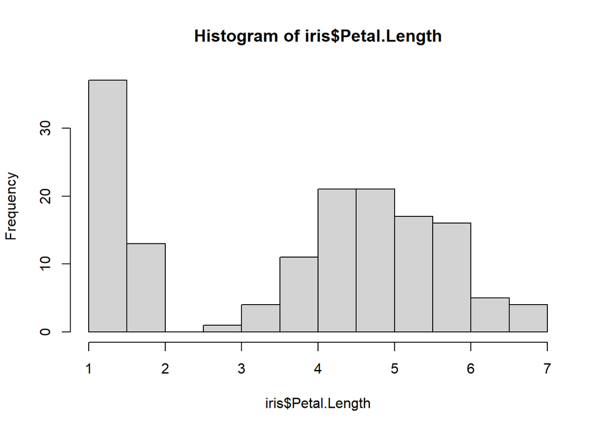

```r
## First we create our simple dataframe again:

iris <- as.data.frame(iris)

## Then we can plot a histogram of petal lengths:
hist(iris$Petal.Length)
```

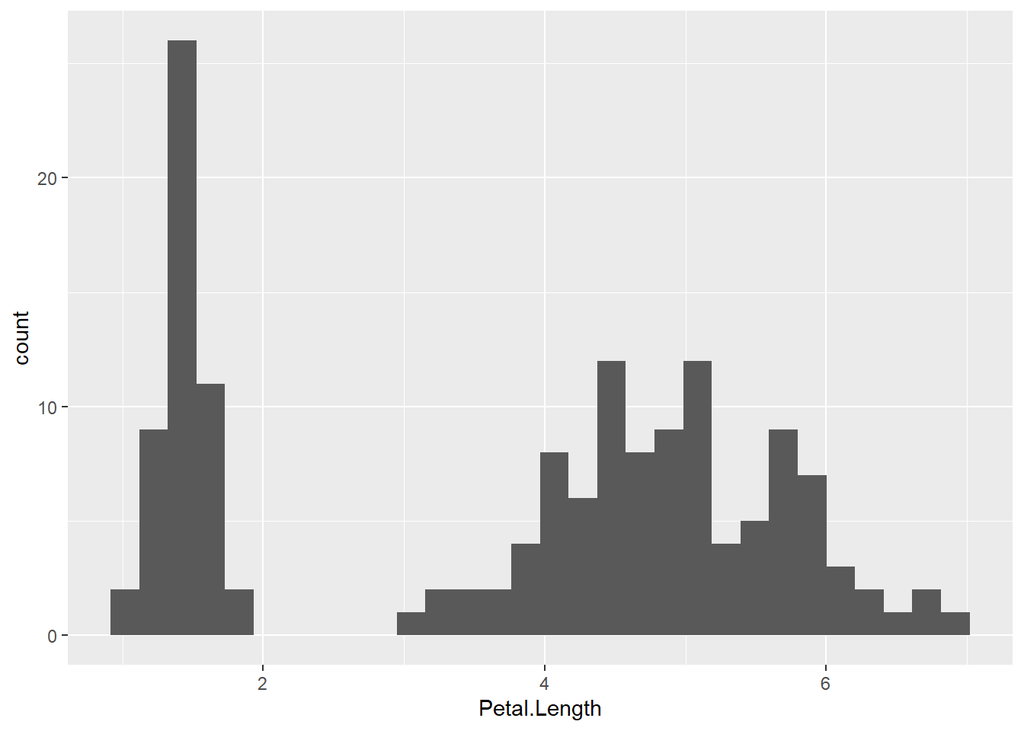

```r
## and the same using ggplot:
ggplot(data = iris) +
  geom_histogram(aes(x = Petal.Length))
```

**Boxplot**

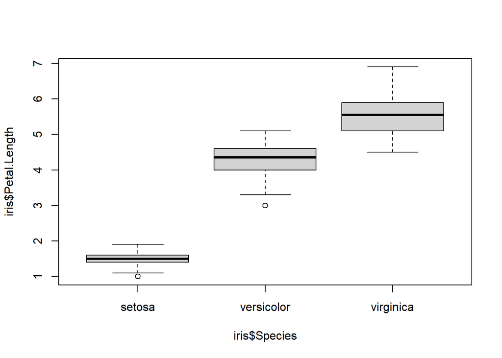

```r
## this is how a boxplot looks using base R functions:
boxplot(iris$Petal.Length~iris$Species)
```

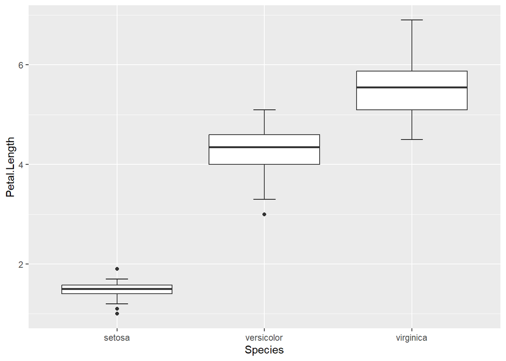

```r
## and this is how a boxplot looks using ggplot:
ggplot(data = iris,aes(x = Species, y = Petal.Length)) +
  stat_boxplot(geom = "errorbar", width = 0.15) +
  geom_boxplot()
```

Note here we have directly made boxplots for the three factors we have in our dataset - we can of course make a boxplot for just one of the factors, but usually when making boxplots we want to compare different factors.

**Scatterplot**

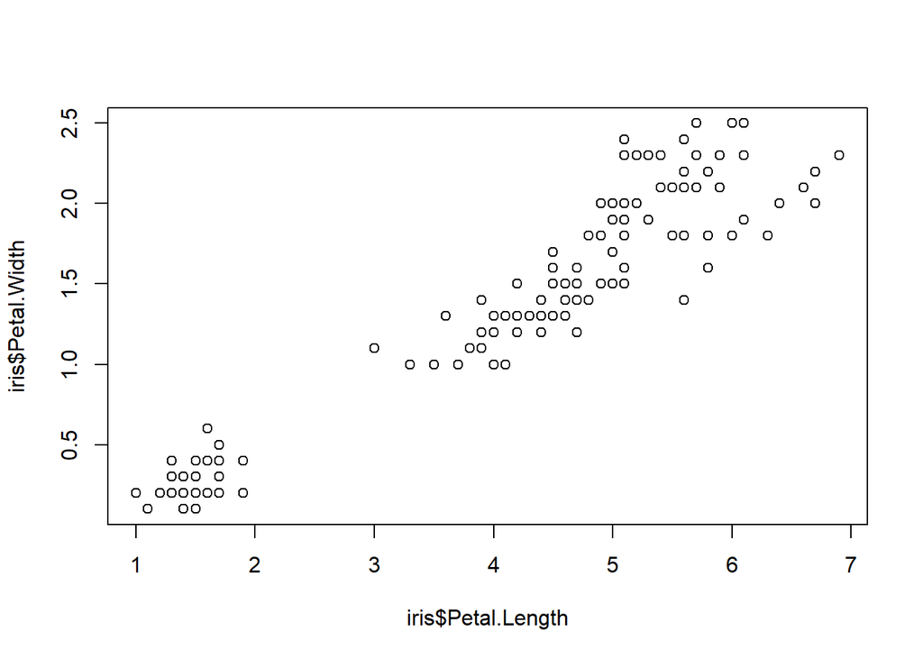

```r
## A scatterplot using base R -- note here a scatterplot is the default that R will return if we don't specify a specific plot and we are plotting two numerical variables
plot(iris$Petal.Width~iris$Petal.Length)
```

```r
## Alternative way of writing this:
# plot(x = iris$Petal.Length, y = iris$Petal.Width)

## This is how a scatterplot looks using ggplot:

ggplot() +
  geom_point(data = iris, aes(x = Petal.Length, y = Petal.Width))
```

[output not shown]

When we don’t specify the type of plot we want, the base function gives us different results based on the class of our variable - this isn’t always informative!!

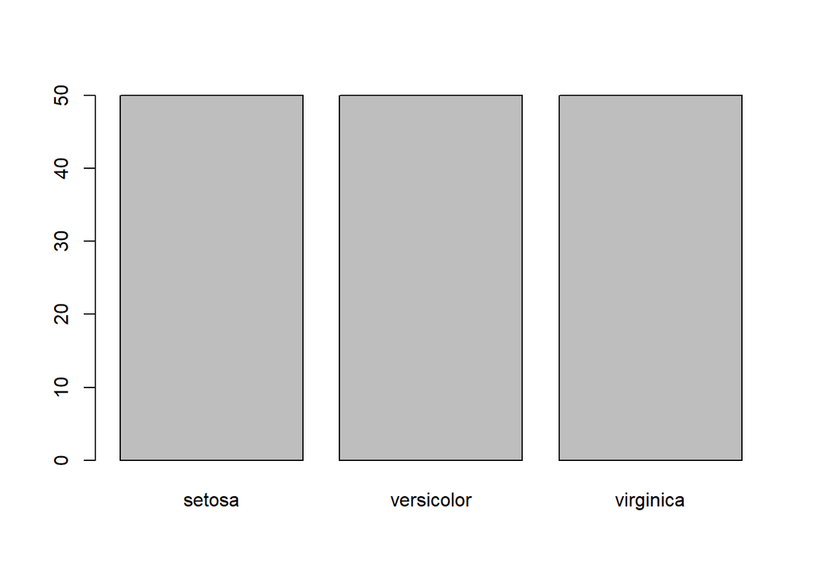

```r
plot(x = iris$Species) # plotting factors for x
```

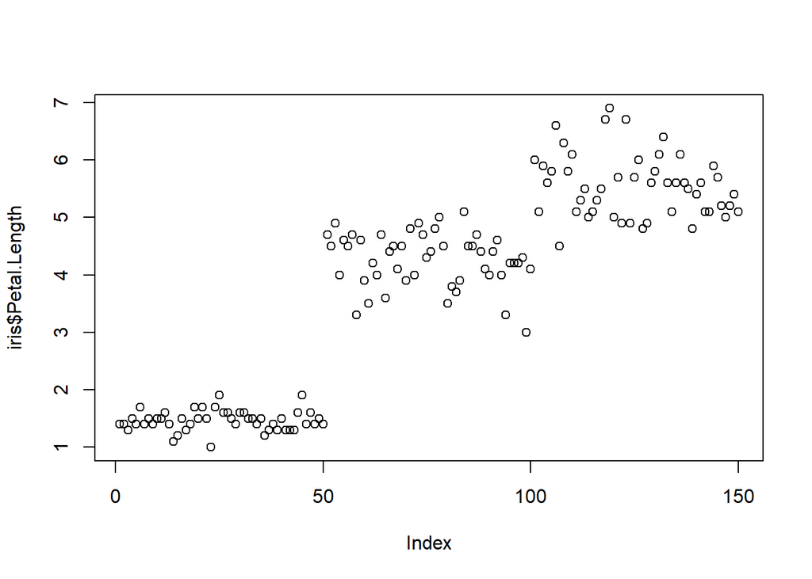

```r
plot(x = iris$Petal.Length) # looks a bit like a histogram? but R returns a scatterplot because it's a numerical value...
```

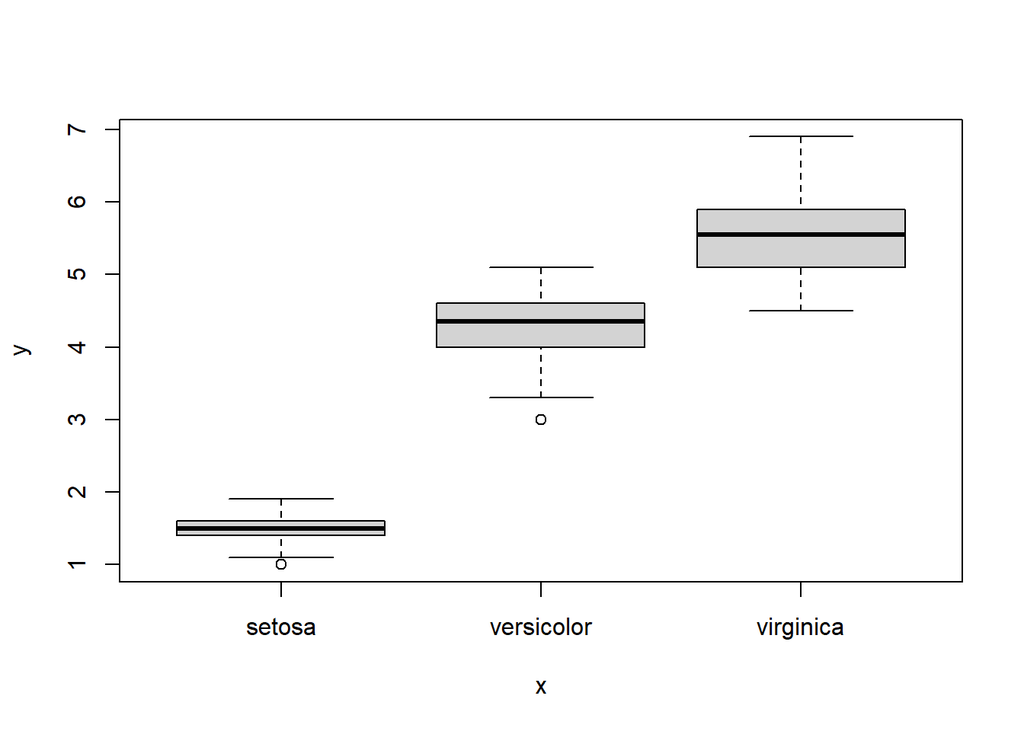

```r
plot(x = iris$Species, y = iris$Petal.Length) # here we get a boxplot because one of our variables is a factor
```

**Line plot**

Let’s revisit the chicks from yesterday

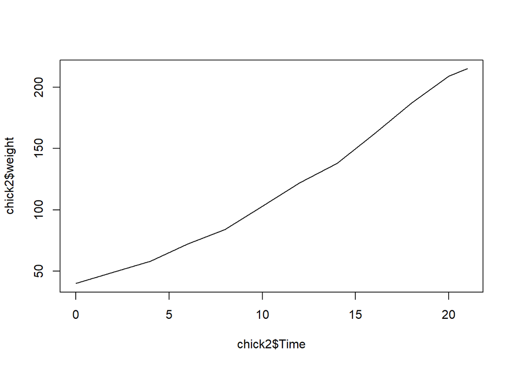

```r
data("ChickWeight")

# Let's plot the weight of chick 2 through time.
chick2 <- ChickWeight[ChickWeight$Chick == 2, ]
plot(x = chick2$Time, y = chick2$weight, type = "l")
```

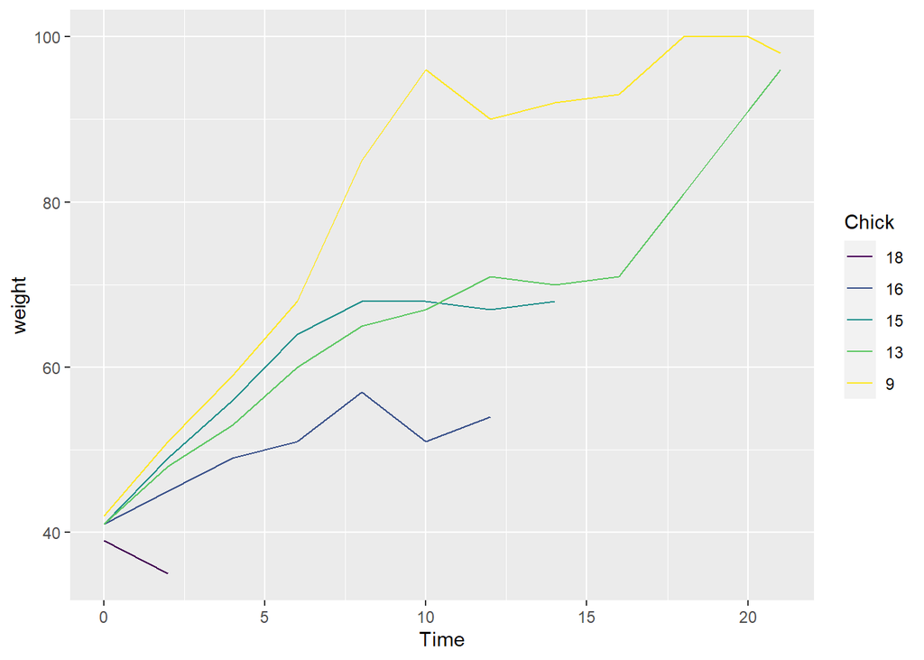

```r
# Now let's plot several chicks using ggplot
ggplot() +
  geom_line(data = ChickWeight[ChickWeight$Chick < 20,], aes(x = Time, y = weight, col = Chick)) # col = Chick tells it to use a different color for each chick so they get their own lines
```

```r
# Maybe it is clear now what happened to chicks 16 and 18. Perhaps they didn't escape after all.
```

**So what’s the difference?**

The two most obvious differences between base R `plot` and `ggplot` are:

- the code/syntax
- the layout and look of the resulting plot

With base R plots, a lot of editing is done with additional lines of code that are technically independent from each other. With ggplot, you add ‘layers’ to your plot object and with each new layer you can either add more data to your plot or change settings.

We will now look at some simple examples on how to customise plots.

## Customising base R plots

Let’s change some basic things about our plot. We’ll start with the base R `plot` function first before we move on to the `ggplot` function.

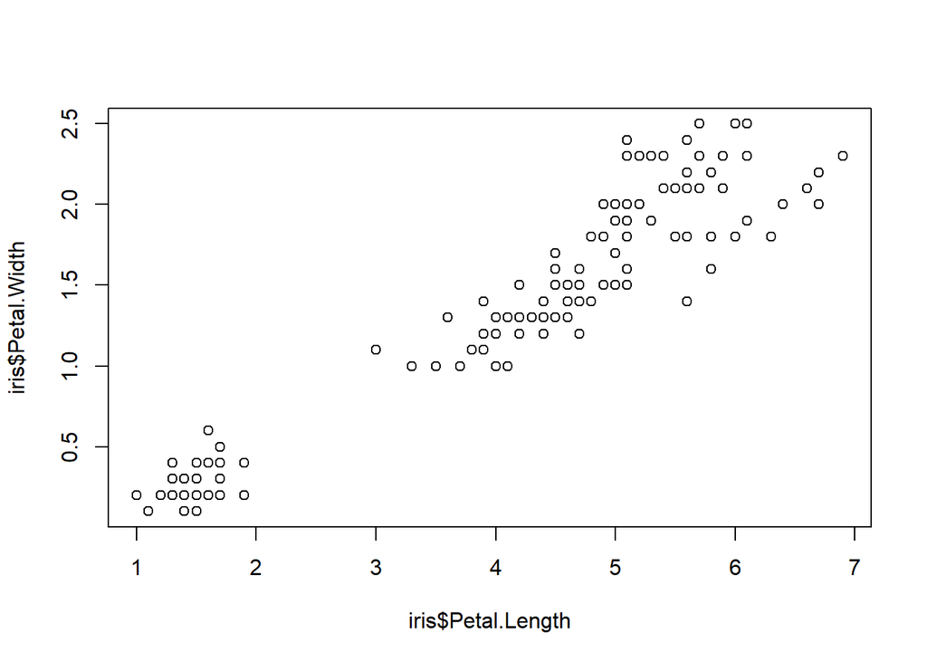

```r
# Load the data:
iris <- as.data.frame(iris)

## Let's remind us of what the plot looks like if we specify nothing else:

plot(iris$Petal.Length, iris$Petal.Width)
```

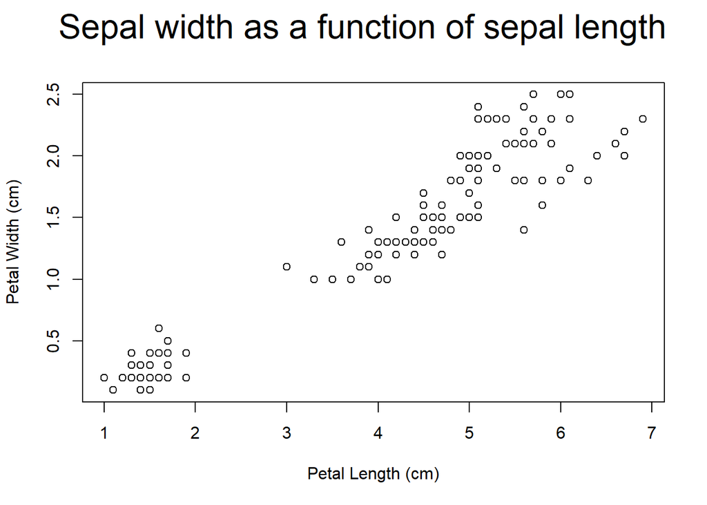

```r
## Now we change the axis titles:

plot(iris$Petal.Length, iris$Petal.Width,
     xlab = "Petal Length (cm)",
     ylab = "Petal Width (cm)")

# And what about a title?

mtext(side=3, line=2, at=0.5, adj=0, cex=2, "Sepal width as a function of sepal length")
```

What if we want to change the colour of our points? Or change the type of symbol completely? R has the following options built in for point symbols:

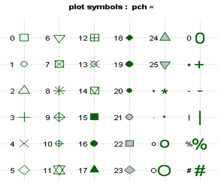

Point types

To use one of these options in our plot, here is how we do it:

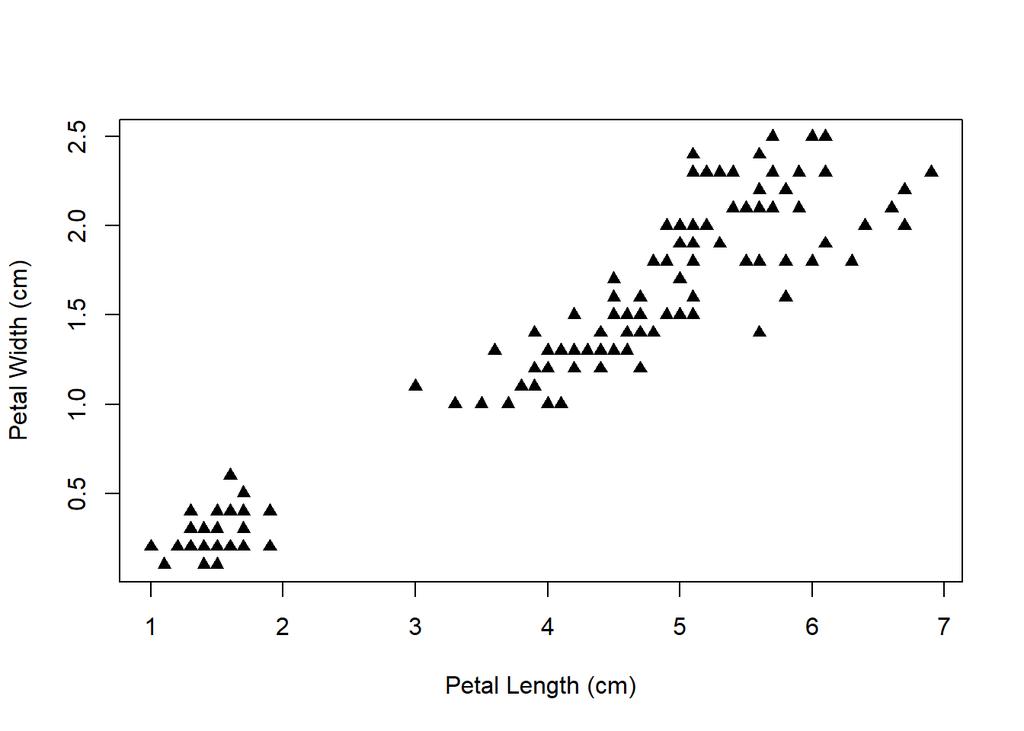

```r
plot(iris$Petal.Length, iris$Petal.Width,
     xlab = "Petal Length (cm)",
     ylab = "Petal Width (cm)",
     pch = 17)
```

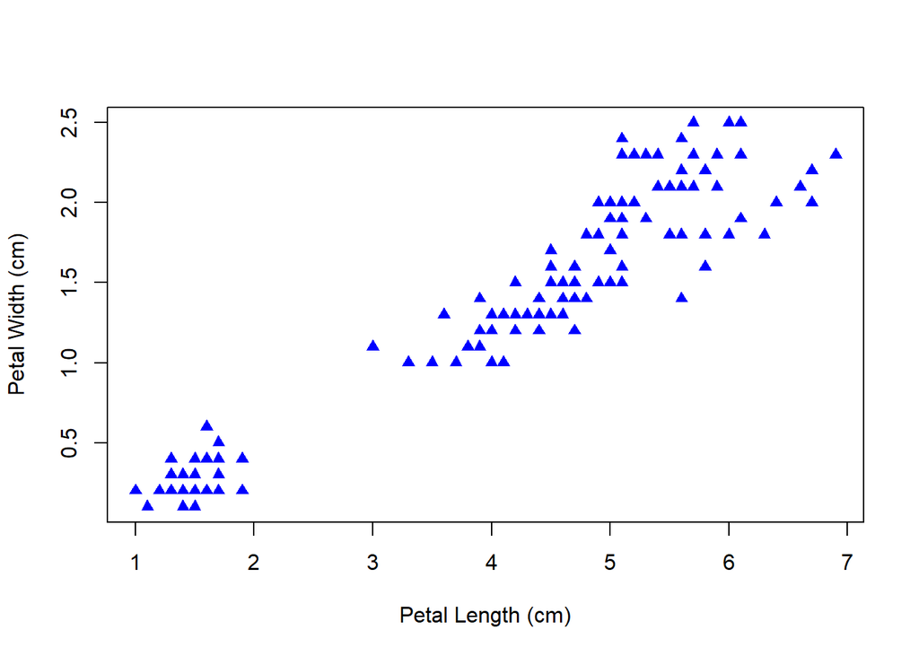

```r
## Or to change the colour on top of it:
plot(iris$Petal.Length, iris$Petal.Width,
     xlab = "Petal Length (cm)",
     ylab = "Petal Width (cm)",
     pch = 17,
     col = "blue")
```

Note how our title disappeared as we didn’t include this command line in our code chunk!

Just as we can change the point symbol, we can also change the line type. Here are the built in options:

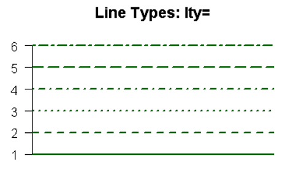

Line types

So if we want to change the line type in our chick plot from earlier it would look like this:

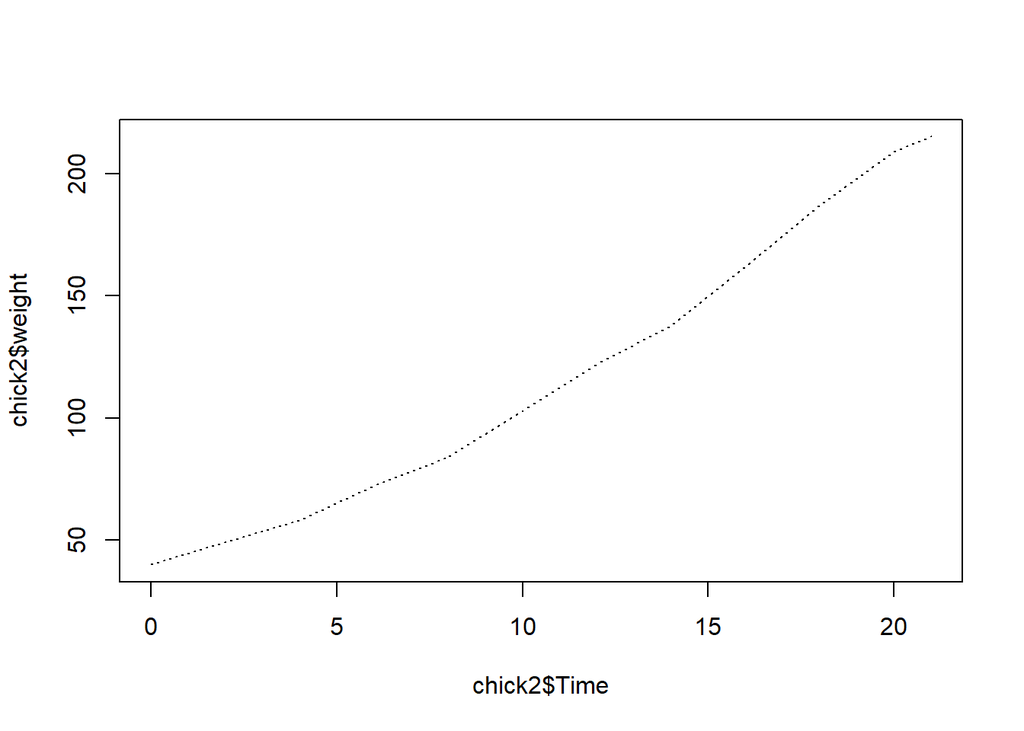

```r
# data("ChickWeight")

chick2 <- ChickWeight[ChickWeight$Chick == 2, ]
plot(x = chick2$Time, y = chick2$weight, type = "l", lty = 3)
```

There are many aspects of a plot that can be edited. Things that directly affect parts of the plot - such as the colour of points - can be specified *within* the `plot` function. Anything that concerns the general layout of the plot - such as margins, font size of labels, position of the legend - need to be specified *outside* the `plot` function. We’ve seen this with the title - we used `mtext()` for this. Another important function is `par()`. Within this function, we can specific parameters that define the general layout of our plot. For example, let’s create very large outer margins, and change the colour of our axis labels to green:

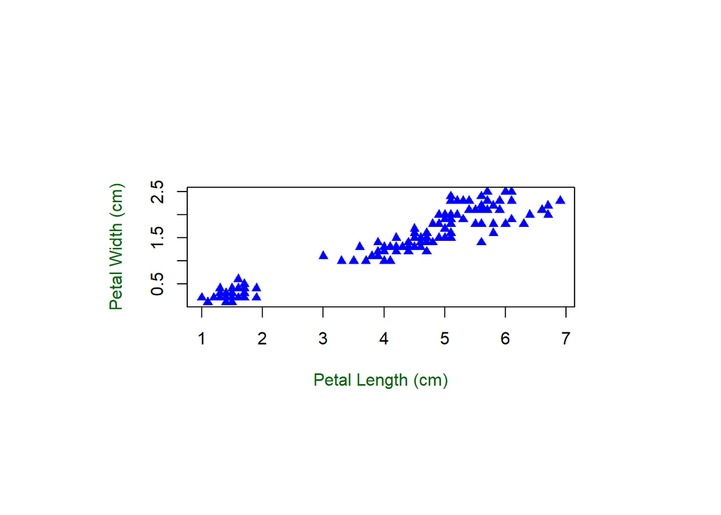

```r
# We have to define out plotting window BEFORE we plot:
par(oma = c(5,5,5,5), col.lab = "darkgreen") # for reference: c(bottom, left, top, right)

plot(iris$Petal.Length, iris$Petal.Width,
     xlab = "Petal Length (cm)",
     ylab = "Petal Width (cm)",
     pch = 17,
     col = "blue")
```

The documentation for this function gives you an overview of all the different parameters that can be changed with this function: https://www.rdocumentation.org/packages/graphics/versions/3.6.2/topics/par

You will find a lot of things will be learned by ‘trial and error’…

**An important note:** the `par` function changes *global* settings for ALL subsequent plots – that means if you want to reset your settings to the default, or you get lost down a rabbit hole and want to start fresh, use `dev.off()`

Final example - let’s group colourings by factor, and add a legend.

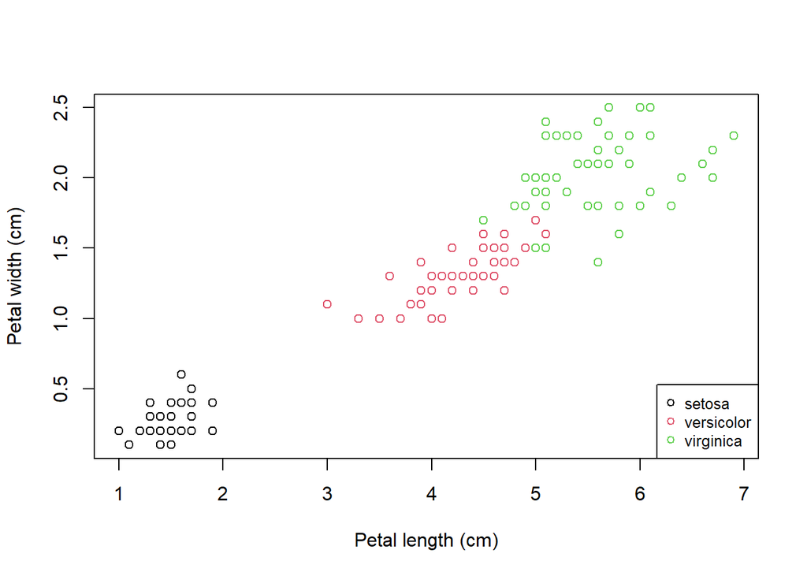

```r
plot(iris$Petal.Length, iris$Petal.Width, col=iris$Species,
     xlab = "Petal length (cm)", ylab = "Petal width (cm)")
legend('bottomright', legend = levels(iris$Species), col = 1:3, cex = 0.8, pch = 1)
```